# Koen 2013

### Experiment summary

Based on previous findings that studied items compared to new ones are not just associated with greater memory strength but also with more variability in memory strengths (old item variance effect), this experiment examined how recognition memory is affected by a test delay of 24 hours. 48 subjects participated in two experimental sessions. In the first session participants had to study a list of words and then completed an immediate recognition test for half of the studied items. 24 hours later, they returned for the second session, the delayed recognition test, for the other half of the studied items.The stimuli consisted of 600 words divided in four groups and counterbalanced, so there was no overlap in the stimuli appearing on the immediate and delayed recognition tests. The results in general provided evidence against the encoding variability account, since the retrieval manipulation affected significantly the estimates of old item variance.

### Some information on the models

**Model Original:** q_2 = q_5, & r_2 = r_5 (all but highest confidence response mapping of uncertainty and detection states equated)  
**Q restricted:** q_2 = q_5 (all but highest confidence response mapping of uncertainty states equated)  
**R restricted:** r_2 = r_5 (all but highest confidence response mapping of detection states equated)

### Some information on convergence

#### For Model Original

One approach failed: partial, TreeBUGS, beta

Frequentist approach with no pooling (asymptotic.no.MPTinR) had 0.646 as proportion of participants with non-identified parameters. Frequentist approach with complete pooling (asymptotic.complete.MPTinR) had no convergence problems.

Bayesian approach with no pooling (simple.no.TreeBUGS) had 9 parameters with Rhat > 1.05 and with complete pooling (simple.complete.TreeBUGS) converged well, all Rhat < 1.05.  
Bayesian approach with partial pooling (trait.partial.Treebugs and trait_uncorrelated.partial.TreeBUGS) converged well, all Rhat < 1.05.

#### For Q restricted

One approach failed: partial, TreeBUGS, beta

Frequentist approach with no pooling (asymptotic.no.MPTinR) had 0.875 as proportion of participants with non-identified parameters. Frequentist approach with complete pooling (asymptotic.complete.MPTinR) had some convergence problems:  
rank.fischer = 4, n.parameters = 10, convergence = 0 (aggregated), 1 (individual)

Bayesian approach with no pooling (simple.no.TreeBUGS) had 2 parameters with Rhat > 1.05 and with complete pooling (simple.complete.TreeBUGS) converged well, all Rhat < 1.05. Bayesian approach with partial pooling (trait.partial.Treebugs and trait_uncorrelated.partial.TreeBUGS) converged well, all Rhat < 1.05.

#### For R restricted

Frequentist approach with no pooling (asymptotic.no.MPTinR) had 0.667 as proportion of participants with non-identified parameters.  
Frequentist approach with complete pooling (asymptotic.complete.MPTinR) had no convergence problems.

Bayesian approach with no pooling (simple.no.TreeBUGS) had 1 parameter with Rhat > 1.05 and with complete pooling (simple.complete.TreeBUGS) converged well, all Rhat < 1.05. Bayesian approach with partial pooling (trait.partial.Treebugs and trait_uncorrelated.partial.TreeBUGS) converged well, all Rhat < 1.05. Bayesian approach with partial pooling (beta.partial.Treebugs) had 1 parameter with Rhat > 1.05.

### Parameter estimation

**Model Original**

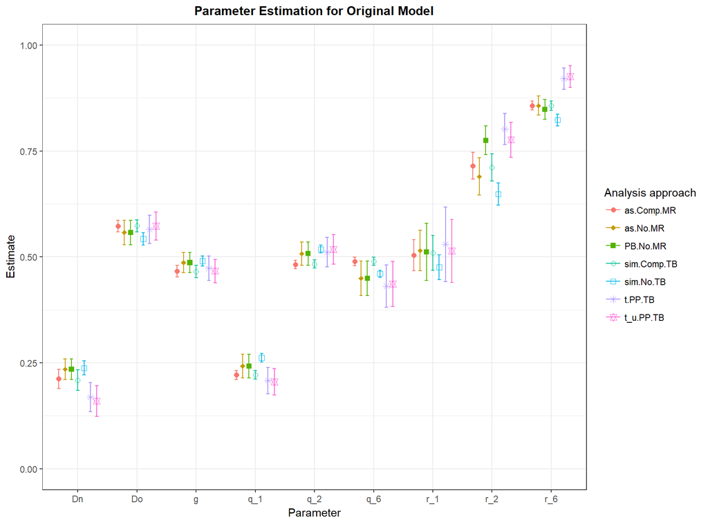

**Q restricted**

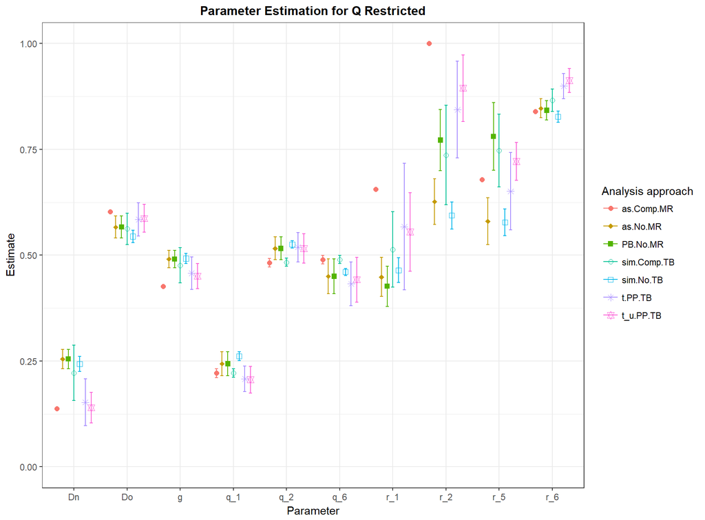

**R restricted**

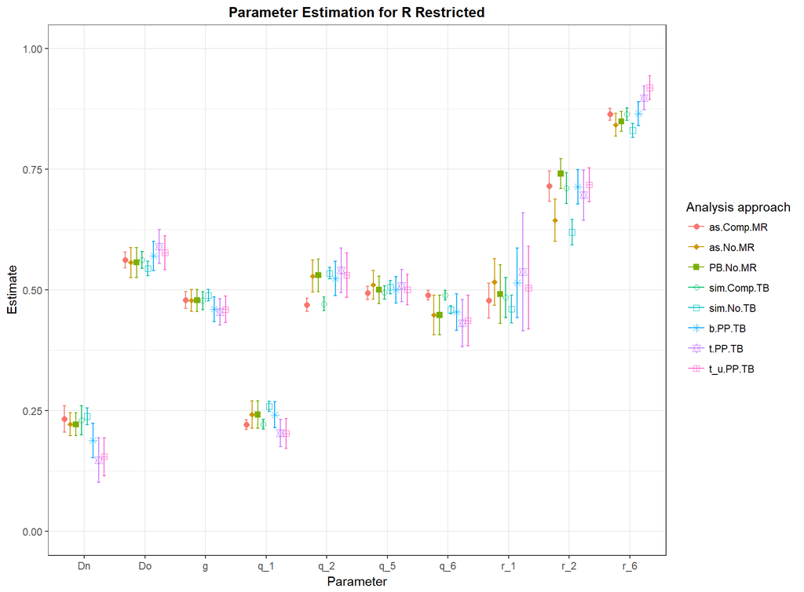

**Core parameters**

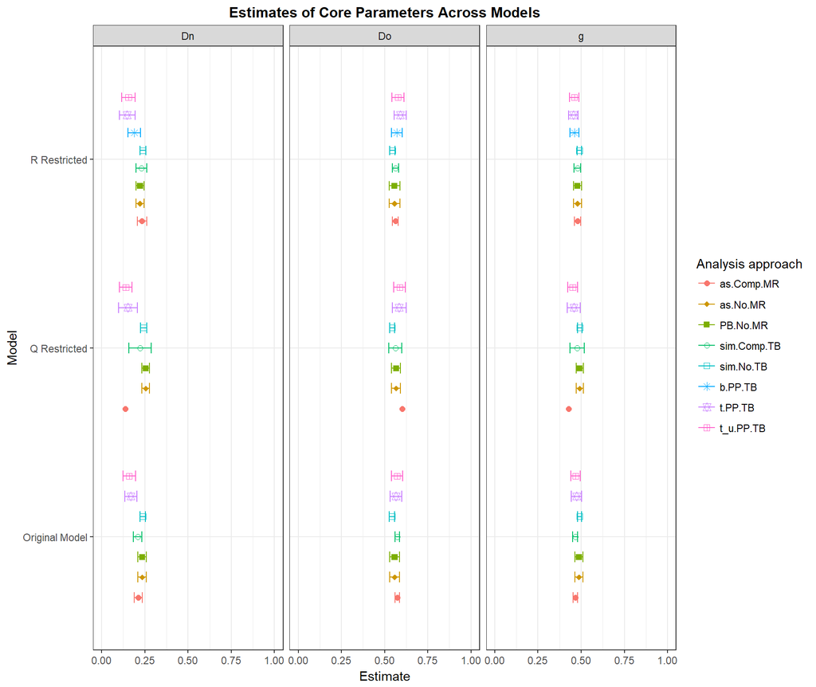

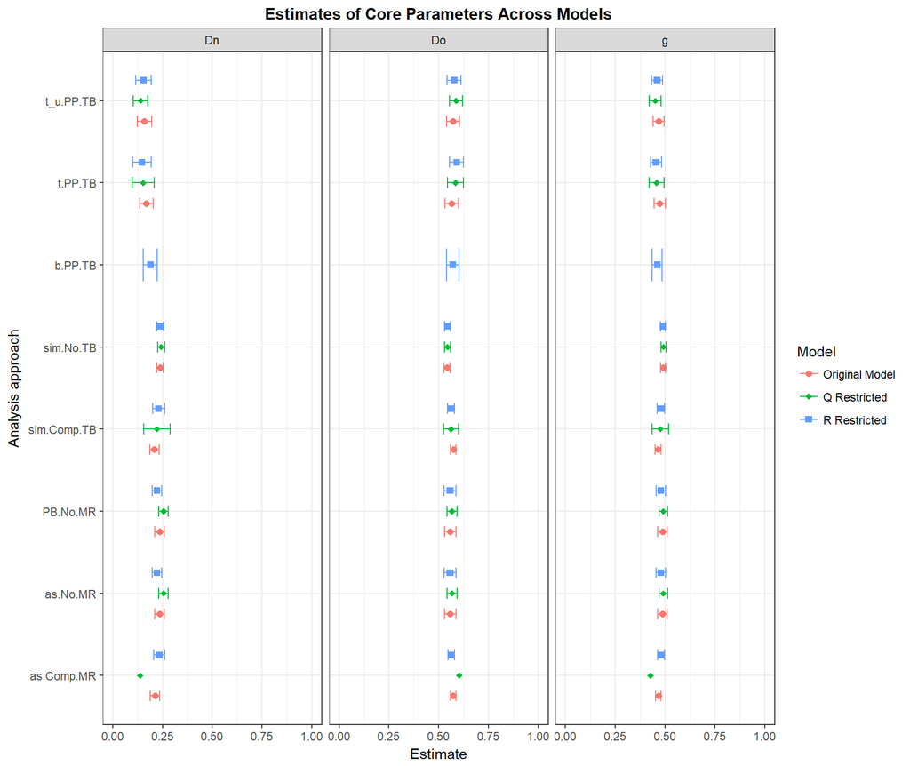

**Q parameters**

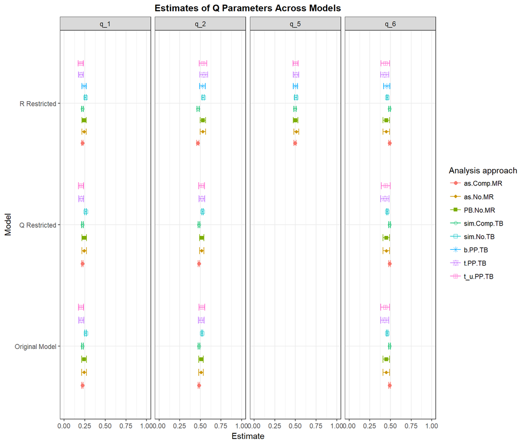

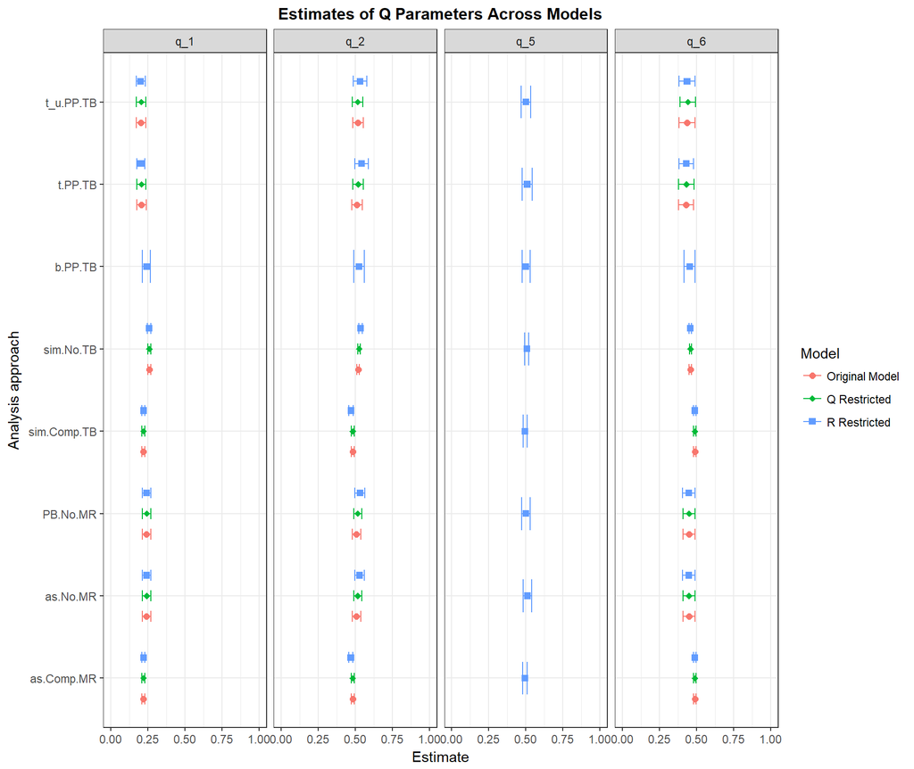

**R parameters**

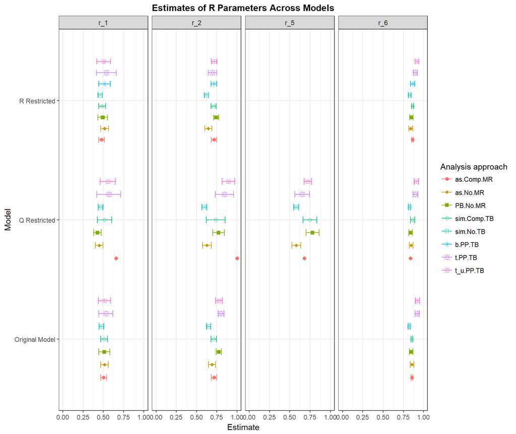

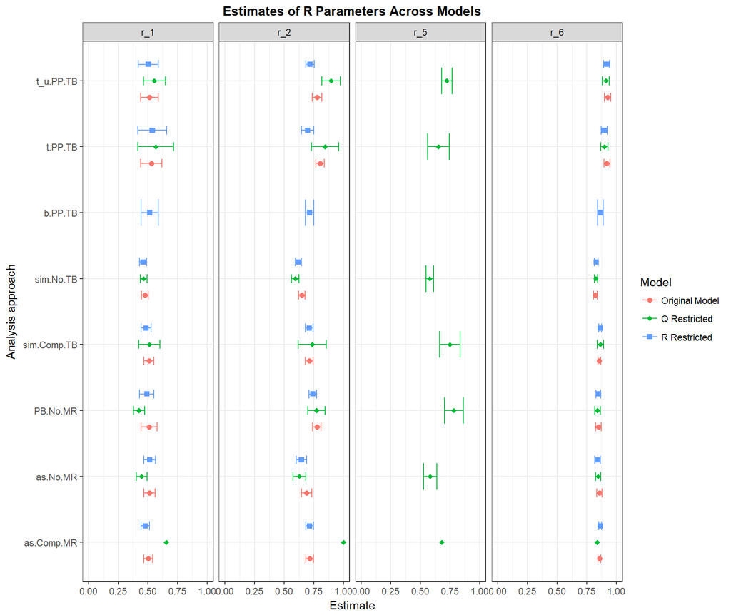

### Goodness of fit

**Model Original**

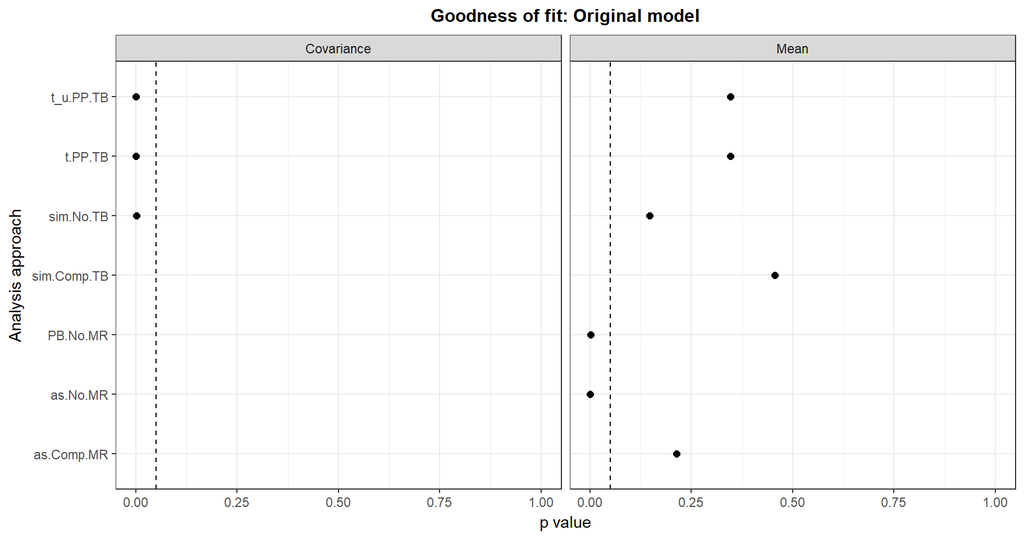

**Q restricted**

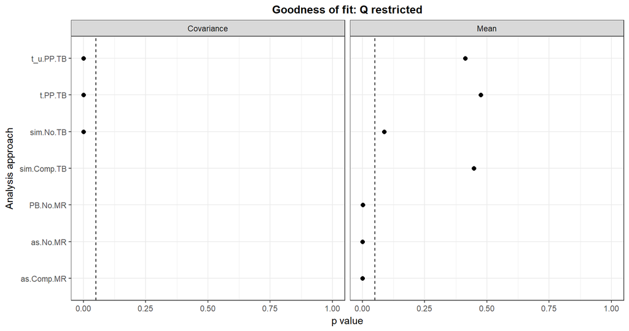

**R restricted**

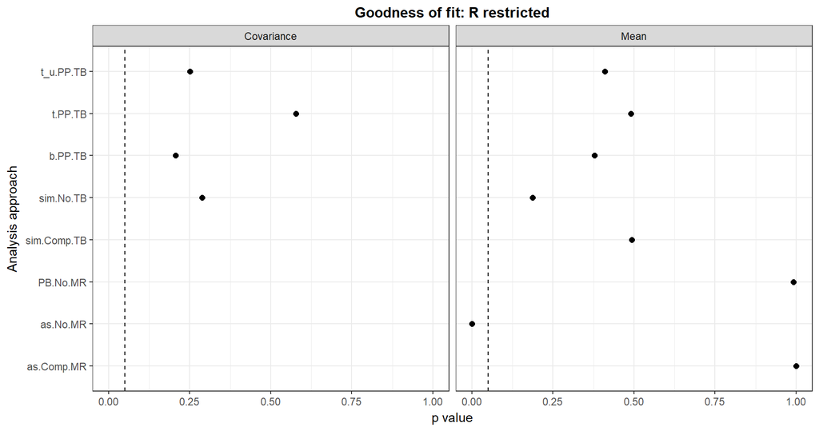